# Modelagem bayesiana

```r
require(rstanarm)
require(dplyr)
```

O inventário florestal é a principal fonte de dados para subsidiar o manejo florestal e, por conseguinte, o planejamento da exploração florestal. Na impossibilidade de se medir toda a floresta, utilizam-se desenhos amostrais para obter estimativas representativas da população de interesse, seja em termos de volume, área basal ou outra variável de interesse. O inventário também pode ser utilizado para avaliar a situação ou modificações na arquitetura, estrutura, composição florística ou impacto da exploração/tratamentos.

No inventário contínuo a amostragem por parcelas permanentes é o procedimento recomendado e o mais empregado para inferir sobre mudanças ocorridas na floresta. Medições sucessivas permitem analisar (a) ingresso: árvore viva que na medição anterior possuía diâmetro inferior ao nível de inclusão e que na medição atual possui diâmetro igual ou superior; (b) mortalidade: árvore viva na ocasião anterior de monitoramento e que estiver morta na ocasião seguinte; e (c) crescimento: Cr = ((Param_t)/(Param_{t-1}) - 1)*100.

## A dúvida

```r
duvida = read.csv('dados/tapajos.csv')
duvida = duvida %>% filter(!is.na(ida))
```

[output not shown]

## A referência

```r
inv = read.csv('dados/cauaxi.csv')
inv = inv %>% filter(!is.na(ida))
```

```r
head(inv)
```

|  | base | nomePopular | nomeCient | familia | deadAno1 | deadAno2 | ingresso | dap1 | dap2 | ida | intervaloMed | ht1 | hcom1 | ht2 | hcom2 | posSocio | luminosidade | classeDiam | classeDiam2 | grupoEco | utmLeste | UTMNorte |
| --- | --- | --- | --- | --- | --- | --- | --- | --- | --- | --- | --- | --- | --- | --- | --- | --- | --- | --- | --- | --- | --- | --- |
| 1 | Cauaxi_PA | macucu | Licania guianensis | Chrysobalanaceae | FALSE | FALSE | NA | 10.3 | 10.3 | 0.00 | 2 | 7.83 | 4.59 | NA | NA | S | 2 | 15 | c015 |  | 778459.7 | 9586872 |
| 2 | Cauaxi_PA | casca seca | Licania canescens | Chrysobalanaceae | FALSE | FALSE | NA | 14.6 | 14.9 | 0.15 | 2 | 10.27 | 9.16 | NA | NA | S | 2 | 15 | c015 |  | 778444.2 | 9586870 |
| 3 | Cauaxi_PA | cajuacu | Anacardium spruceanum | Anacardiaceae | FALSE | FALSE | NA | 78.8 | 78.9 | 0.05 | 2 | 31.65 | 21.06 | NA | NA | E | 1 | 75 | c075 |  | 778443.5 | 9586872 |
| 4 | Cauaxi_PA | breu branco | Protium paniculatum | Burseraceae | FALSE | FALSE | NA | 14.7 | 14.7 | 0.00 | 2 | 11.54 | 7.35 | NA | NA | S | 2 | 15 | c015 |  | 778443.2 | 9586870 |
| 5 | Cauaxi_PA | breu branco | Protium paniculatum | Burseraceae | FALSE | FALSE | NA | 10.6 | 10.6 | 0.00 | 2 | 6.91 | 4.90 | NA | NA | E | 3 | 15 | c015 |  | 778436.2 | 9586869 |
| 6 | Cauaxi_PA | caramuxi | Pouteria hispida | Sapotaceae | FALSE | FALSE | NA | 27.1 | 27.7 | 0.30 | 2 | 19.83 | 13.53 | NA | NA | C | 2 | 25 | c025 |  | 778433.7 | 9586869 |

O analista deseja saber se o valores de incremento apresentado pela empresa está dentro do que se conhece sobre a área. Para isto, ele vai usar a estatisticas Bayesiama para analisar os dados.

```r
post = stan_glm(ida ~ 1,
                family = gaussian(link = 'identity'),
                data = duvida,
                prior_intercept = normal(0.43, 0.80))
```

```r
post
```

```
stan_glm
 family:       gaussian [identity]
 formula:      ida ~ 1
 observations: 773
 predictors:   1
------
            Median MAD_SD
(Intercept) 0.5    0.0

Auxiliary parameter(s):
      Median MAD_SD
sigma 0.8    0.0

------
* For help interpreting the printed output see ?print.stanreg
* For info on the priors used see ?prior_summary.stanreg
```

```
Drawing from prior...
```

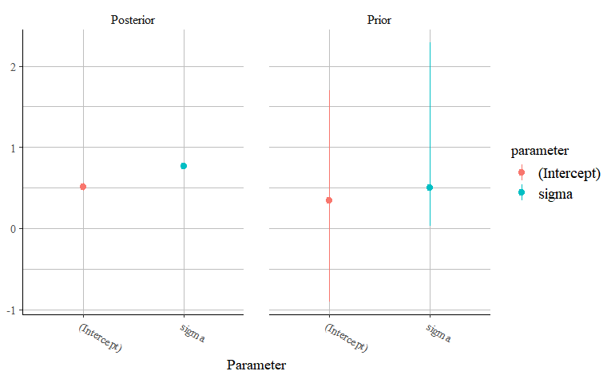

```r
posterior_vs_prior(post, prob = 0.9)
```